# GREENGrid Household Electricity Demand Data Test

Imputed total power demand using: circuitsToSum_v1.1

Ben Anderson (b.anderson@soton.ac.uk, `@dataknut`)

Last run at: 2019-05-21 16:28:46

# 1 About

## 1.1 Report circulation:

- Public - this report is intended to accompany the data release.

## 1.2 License

This work is made available under the Creative Commons [Attribution-ShareAlike 4.0 International (CC BY-SA 4.0) License](https://creativecommons.org/licenses/by-sa/4.0/).

This means you are free to:

- *Share* — copy and redistribute the material in any medium or format
- *Adapt* — remix, transform, and build upon the material for any purpose, even commercially.

Under the following terms:

- *Attribution* — You must give appropriate credit, provide a link to the license, and indicate if changes were made. You may do so in any reasonable manner, but not in any way that suggests the licensor endorses you or your use.
- *ShareAlike* — If you remix, transform, or build upon the material, you must distribute your contributions under the same license as the original.
- *No additional restrictions* — You may not apply legal terms or technological measures that legally restrict others from doing anything the license permits.

**Notices:**

- You do not have to comply with the license for elements of the material in the public domain or where your use is permitted by an applicable exception or limitation.
- No warranties are given. The license may not give you all of the permissions necessary for your intended use. For example, other rights such as publicity, privacy, or moral rights may limit how you use the material. #YMMV

For the avoidance of doubt and explanation of terms please refer to the full [license notice](https://creativecommons.org/licenses/by-sa/4.0/) and [legal code](https://creativecommons.org/licenses/by-sa/4.0/legalcode).

## 1.3 Citation

If you wish to use any of the material from this report please cite as:

- Anderson, B. (2019) GREENGrid Household Electricity Demand Data TestImputed total power demand using: circuitsToSum_v1.1. [Centre for Sustainability](http://www.otago.ac.nz/centre-sustainability/), University of Otago: Dunedin.

This work is (c) 2019 the University of Otago

## 1.4 History

- [Report history](https://github.com/CfSOtago/GREENGridData/commits/master/examples/code/imputeTotalDemandFromCleanGridSpy1min.Rmd)

## 1.5 Requirements:

This report uses the safe version of the grid spy 1 minute data which has been processed using the code in https://github.com/CfSOtago/GREENGridData/tree/master/dataProcessing/gridSpy.

## 1.6 Support

This work was supported by:

- The [University of Otago](https://www.otago.ac.nz/);
- The [University of Southampton](https://www.southampton.ac.uk/);
- The New Zealand [Ministry of Business, Innovation and Employment (MBIE)](http://www.mbie.govt.nz/) through the [NZ GREEN Grid](https://www.otago.ac.nz/centre-sustainability/research/energy/otago050285.html) grant (Contract ID: UOCX1203);
- [SPATIALEC](http://www.energy.soton.ac.uk/tag/spatialec/) - a [Marie Skłodowska-Curie Global Fellowship](http://ec.europa.eu/research/mariecurieactions/about-msca/actions/if/index_en.htm) based at the University of Otago’s [Centre for Sustainability](http://www.otago.ac.nz/centre-sustainability/staff/otago673896.html) (2017-2019) & the University of Southampton’s Sustainable Energy Research Group (2019-202).

# 2 Introduction

The [NZ GREEN Grid household electricity demand study](https://cfsotago.github.io/GREENGridData/) recruited a sample of c 25 households in each of two regions of New Zealand (Stephenson et al. 2017). The first sample was recruited in early 2014 and the second in early 2015. Research data includes:

- 1 minute electricity power (W) data was collected for each dwelling circuit using [GridSpy](https://gridspy.com/) monitors on each power circuit (and the incoming power). The power values represent mean(W) over the minute preceeding the observation timestamp;
- Dwelling & appliance surveys;
- Occupant time-use diaries (focused on energy use).

NB: Version 1 of the data package does not include the time-use diaries.

This report provides summary analysis of the imputed total demand for each household. The imputation was done using:

- circuitsToSum_v1.1

# 3 Load data

Table 3.1: First few rows of grid spy data

| linkID | dateTime_utc | imputedTotalW |
| --- | --- | --- |
| rf_01 | 2015-03-31 11:00:00 | 173.23 |
| rf_01 | 2015-03-31 11:01:00 | 175.59 |
| rf_01 | 2015-03-31 11:02:00 | 172.74 |
| rf_01 | 2015-03-31 11:03:00 | 179.40 |
| rf_01 | 2015-03-31 11:04:00 | 380.29 |
| rf_01 | 2015-03-31 11:05:00 | 350.85 |

Table 3.1 shows the first few rows of the Grid Spy 1 minute power data. Table 3.2 shows a summary of the Grid Spy 1 minute power data (for more detail see Section 7.1).

Table 3.2: Summary of grid spy data

|  | linkID | dateTime_utc | imputedTotalW | dateTime_nz | obsTimeHMS |
| --- | --- | --- | --- | --- | --- |
|  | Length:18188665 | Min. :2015-03-31 11:00:00 | Min. :-8713.1 | Min. :2015-04-01 00:00:00 | Length:18188665 |
|  | Class :character | 1st Qu.:2015-06-17 15:37:00 | 1st Qu.: 206.3 | 1st Qu.:2015-06-18 03:37:00 | Class1:hms |
|  | Mode :character | Median :2015-09-12 01:45:00 | Median : 417.3 | Median :2015-09-12 13:45:00 | Class2:difftime |
|  | NA | Mean :2015-09-18 01:23:30 | Mean : 887.9 | Mean :2015-09-18 13:23:30 | Mode :numeric |
|  | NA | 3rd Qu.:2015-12-15 14:51:00 | 3rd Qu.: 1158.3 | 3rd Qu.:2015-12-16 03:51:00 | NA |
|  | NA | Max. :2016-03-31 10:59:00 | Max. :13999.8 | Max. :2016-03-31 23:59:00 | NA |

Note that:

- dateTime_utc is the correct dateTime of each observation in UTC. You may get strange results until you use [lubridate](https://lubridate.tidyverse.org/) to tell R to use tz = “Pacific/Auckland” with this variable;
- there can be 0 or negative Wh observations.

Table 3.3 shows the summaries for each household as imputed using circuitsToSum_v1.1. Note that the presence of a PV inverter may only be known from the appliance summary and/or the household data.

The number of households excluded will depend on the circuits file used:

- v1.0:
  - no PV
  - no -ve values (?)
- v1.1:
  - no exclusions

Table 3.3: Summary of monitored households (NA indicates data not included in circuitsToSum_v1.1)

| linkID | hasHhData | hasApplianceSummary | pvInverter | energyStorage | notes | nObs | minW | maxW | Circuit 1 | Circuit 2 | Circuit 3 |
| --- | --- | --- | --- | --- | --- | --- | --- | --- | --- | --- | --- |
| rf_01 | No | No | Not known | Not known |  | 291480 | 0.00 | 13448.70 | mains$1634 |  |  |
| rf_02 | No | No | Not known | Not known |  | 82367 | 22.21 | 10204.00 | Mains$1575 |  |  |
| rf_06 | Yes | No | Not known | Not known |  | 523193 | 103.00 | 9975.92 | Hot Water - Controlled$2248 | Incomer - Uncontrolled$2249 |  |
| rf_07 | Yes | No | Not known | Not known |  | 508692 | 16.00 | 9508.46 | Incomer 1 - Uncontrolled$2726 | Incomer 2 - Uncontrolled$2725 |  |
| rf_08 | Yes | No | Not known | Not known |  | 521723 | 133.89 | 11556.80 | Incomer - Uncontrolled$2093 | Hot Water - Controlled$2094 |  |
| rf_09 | Yes | No | Not known | Not known |  | 153389 | -16.00 | 8586.00 | Incomer 1 - Uncont - Inc Hob$2729 | Incomer 2 - Uncont - Inc Oven$2730 |  |
| rf_10 | Yes | Yes | No | No |  | 526678 | 27.68 | 9160.32 | Incomer - All$2599 |  |  |
| rf_11 | Yes | Yes | No | No |  | 519067 | 15.00 | 10955.77 | Incomer - Uncontrolled$2585 | Hot Water Cpbd Heater- Cont$2586 | Spa - Uncontrolled$2587 |
| rf_12 | Yes | No | Not known | Not known |  | 80801 | -406.00 | 8779.69 | Incomer 1 - Hot Water - Cont$2626 | Incomer 2 - Uncontrolled$2625 | Incomer 3 - Uncontrolled$2627 |
| rf_13 | Yes | Yes | No | No |  | 526809 | 163.04 | 11580.60 | Incomer - Uncontrolled$2209 |  |  |
| rf_14 | Yes | Yes | No | No |  | 525358 | -1758.08 | 8272.14 | Incomer 1 - Uncont inc Stove$2718 | Incomer 2 - Uncont inc Oven$2717 | Hot Water - Controlled$2719 |
| rf_15a | Yes | No | Not known | Not known | Disconnected 15/01/2015. Re-used | NA | NA | NA | NA | NA | NA |
| rf_15b | Yes | No | Not known | Not known | Re-user. Then disconnected 02/04/2016 | 273972 | -1062.00 | 10260.80 | Incomer 1$3956 | Incomer 2$3955 |  |
| rf_16 | Yes | No | Not known | Not known |  | NA | NA | NA | Incomer 1 - Uncont inc Oven$2681 | Incomer 2 - Uncont inc Stove$2680 | Hot Water - Controlled$2679 |
| rf_17a | Yes | No | Not known | Not known | Unusual & specialist energy tech configuration. Disconnected 28/03/2016. Re-used. | 520688 | -1084.72 | 9041.53 | Incomer 1 - Uncont - inc Hob$2152 | Incomer 2 - Uncont - inc Oven$2151 | Hot Water - Controlled$2150 |
| rf_17b | Yes | No | Not known | Not known | Re-user | NA | NA | NA | Incomer 1 - inc Top Oven$5620 | Incomer 2 - inc Bottom Oven$5621 |  |
| rf_18 | Yes | No | Not known | Not known |  | 102922 | -1099.00 | 12659.66 | Incomer 1 - Uncontrolled$2128 | Incomer 2 - Uncontrolled$2130 | Hot Water - Controlled$2129 |
| rf_19 | Yes | Yes | yes | No |  | 526416 | -8713.10 | 7363.92 | Incomer 1 - All$2738 | Incomer 2 - All$2737 |  |
| rf_20 | Yes | No | Not known | Not known |  | 102908 | -137.45 | 9739.43 | Incomer 1 - Uncontrolled$2112 | Incomer 2 - Uncontrolled$2111 | Hot Water - Controlled$2110 |
| rf_21 | Yes | Yes | No | No |  | 504923 | 31.00 | 6835.12 | Incomer - All$2748 |  |  |
| rf_22 | Yes | Yes | No | No |  | 525979 | 50.25 | 11535.40 | Incomer - Uncontrolled$2237 | Hot Water - Controlled$2236 |  |
| rf_23 | Yes | Yes | yes | yes |  | 519787 | -1871.83 | 11015.80 | Incomer - Uncontrolled$2082 | Hot Water - Controlled (HEMS)$2081 |  |
| rf_24 | Yes | Yes | yes | No |  | 520436 | -4713.95 | 9929.11 | Incomer - Uncontrolled$2101 | Hot Water - Controlled$2102 |  |
| rf_25 | Yes | Yes | No | No |  | 443096 | 0.00 | 10163.25 | Incomer 1 - Uncontrolled $2763 | Incomer 2 - Uncontrolled $2762 |  |
| rf_26 | Yes | Yes | No | No |  | 522486 | -421.25 | 8814.36 | Incomer 1 - All$2703 | Incomer 2 - All$2704 |  |
| rf_27 | Yes | Yes | No | No |  | 497686 | 58.00 | 9569.40 | Incomer - Uncontrolled$2824 | Hot Water - Controlled$2825 |  |
| rf_28 | Yes | Yes | yes | No |  | 79805 | -3366.52 | 7960.34 | Incomer - All$4221 |  |  |
| rf_29 | Yes | Yes | No | No |  | 526661 | 115.89 | 11053.34 | Incomer - Uncontrolled$4181 | Hot Water - Controlled$4184 |  |
| rf_30 | Yes | Yes | No | No |  | 477371 | 30.00 | 8706.07 | Incomer - All$4239 |  |  |
| rf_31 | Yes | Yes | No | No |  | 526761 | 24.00 | 9429.64 | Incomer - All$4199 |  |  |
| rf_32 | Yes | Yes | No | No |  | 526665 | 0.00 | 8274.91 | Incomer - All$4193 |  |  |
| rf_33 | Yes | Yes | No | No |  | 526743 | 69.20 | 9654.25 | Incomer - Uncontrolled$4143 | Hot Water - Controlled$4144 |  |
| rf_34 | Yes | Yes | No | No |  | 526557 | 74.00 | 13043.50 | Incomer - All$4225 |  |  |
| rf_35 | Yes | Yes | No | No |  | 328634 | -622.00 | 10373.54 | Incomer - Uncontrolled$4126 | Hot Water - Uncontrolled$4125 |  |
| rf_36 | Yes | Yes | No | No |  | 516127 | 0.00 | 11493.20 | Incomer - All$4148 |  |  |
| rf_37 | Yes | Yes | No | No |  | 526651 | 51.00 | 9365.54 | Incomer -Uncontrolled$4136 | Hot Water - Controlled$4135 |  |
| rf_38 | Yes | Yes | No | No | very large number of circuits | 374442 | -179.00 | 9073.99 | Incomer - Uncontrolled$4177 | Hot Water - Controlled$4178 |  |
| rf_39 | Yes | Yes | No | No |  | 495686 | -199.00 | 13999.81 | Incomer - Uncontrolled$4248 | Hot Water (2 elements)$4247 |  |
| rf_40 | Yes | Yes | No | No |  | 338949 | 24.00 | 12527.77 | Incomer - Uncontrolled$4168 | Hot Water - Controlled$4167 |  |
| rf_41 | Yes | Yes | No | No |  | 224546 | 56.00 | 10004.40 | Incomer - All$4192 |  |  |
| rf_42 | Yes | Yes | No | No |  | 518065 | 35.08 | 11786.40 | Incomer - All$4132 |  |  |
| rf_43 | Yes | No | Not known | Not known |  | 289563 | 0.00 | 6687.53 | Incomer - All$4213 |  |  |
| rf_44 | Yes | Yes | No | No |  | 526738 | 32.00 | 12165.12 | Incomer - Uncontrolled$4156 | Hot Water - Controlled$4155 |  |
| rf_45 | Yes | Yes | No | No |  | 525994 | 23.90 | 10385.13 | Incomer - Uncontrolled$4157 | Hot Water - Controlled$4158 |  |
| rf_46 | Yes | Yes | No | No |  | 486863 | 92.00 | 10305.78 | Incomer - Uncontrolled$4230 | Hot Water - Controlled$4231 |  |
| rf_47 | Yes | Yes | No | No |  | 524988 | 21.00 | 11171.30 | Incomer - All$4170 |  |  |

# 4 Test 0 and -ve power value incidence

Figure 4.1 shows the incidence of -ve overall imputed power values by linkID (household) and date. As we can see they tend to be concentrated in a few households.

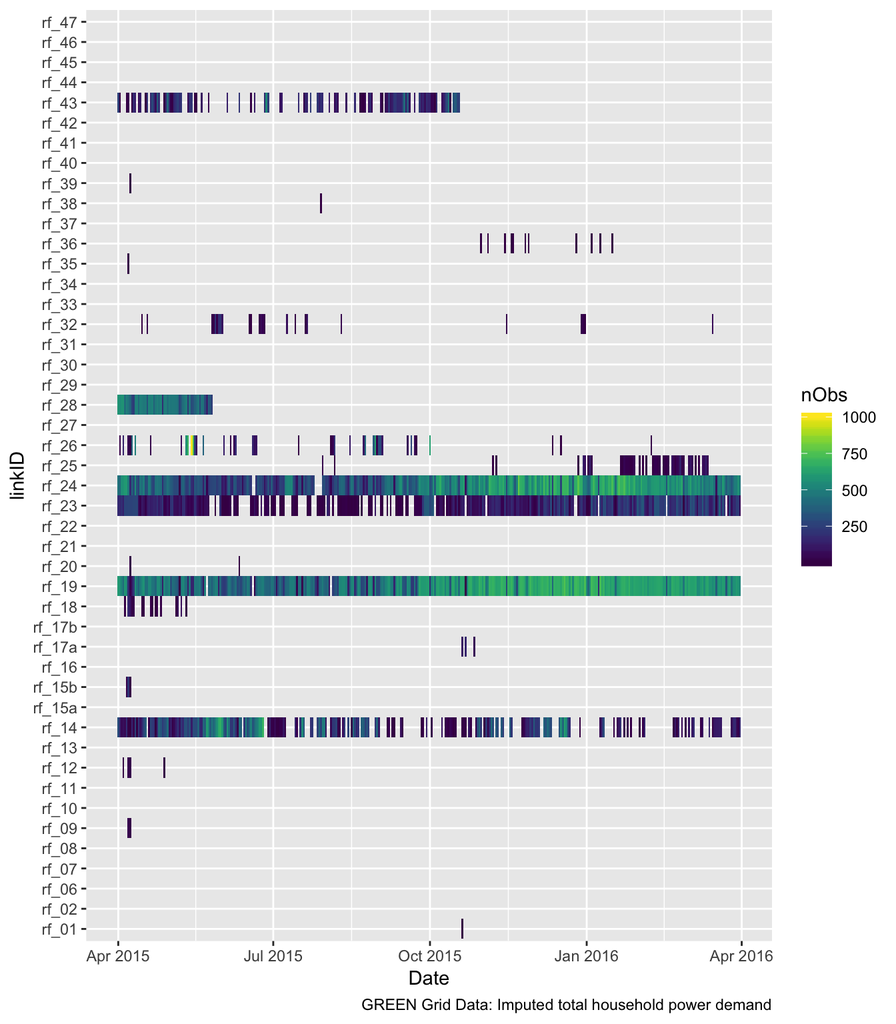

Figure 4.1: Incidence of -ve values by household ID, date and presence of PV (if known)

Table 4.1: Number of observations of 0 or -ve total W by presence of PV

| pvInverter | nObs | nHouseholds |
| --- | --- | --- |
| No | 59978 | 27 |
| Not known | 16538 | 15 |
| yes | 400025 | 4 |

Table 4.2: Summary of monitored households (NA indicates data not included in circuitsToSum_v1.1)

| linkID | pvInverter | energyStorage | notes | nObs | minW | maxW | Circuit 1 | Circuit 2 | Circuit 3 |
| --- | --- | --- | --- | --- | --- | --- | --- | --- | --- |
| rf_19 | yes | No |  | 526416 | -8713.10 | 7363.92 | Incomer 1 - All$2738 | Incomer 2 - All$2737 |  |
| rf_23 | yes | yes |  | 519787 | -1871.83 | 11015.80 | Incomer - Uncontrolled$2082 | Hot Water - Controlled (HEMS)$2081 |  |
| rf_24 | yes | No |  | 520436 | -4713.95 | 9929.11 | Incomer - Uncontrolled$2101 | Hot Water - Controlled$2102 |  |
| rf_28 | yes | No |  | 79805 | -3366.52 | 7960.34 | Incomer - All$4221 |  |  |

Figure 4.2 shows the mean overall imputed power values by linkID (household) and date where power <= 0. As we can see they tend to be concentrated in a few households with some reporting persistent -ve values even though they do not appear to have PV.

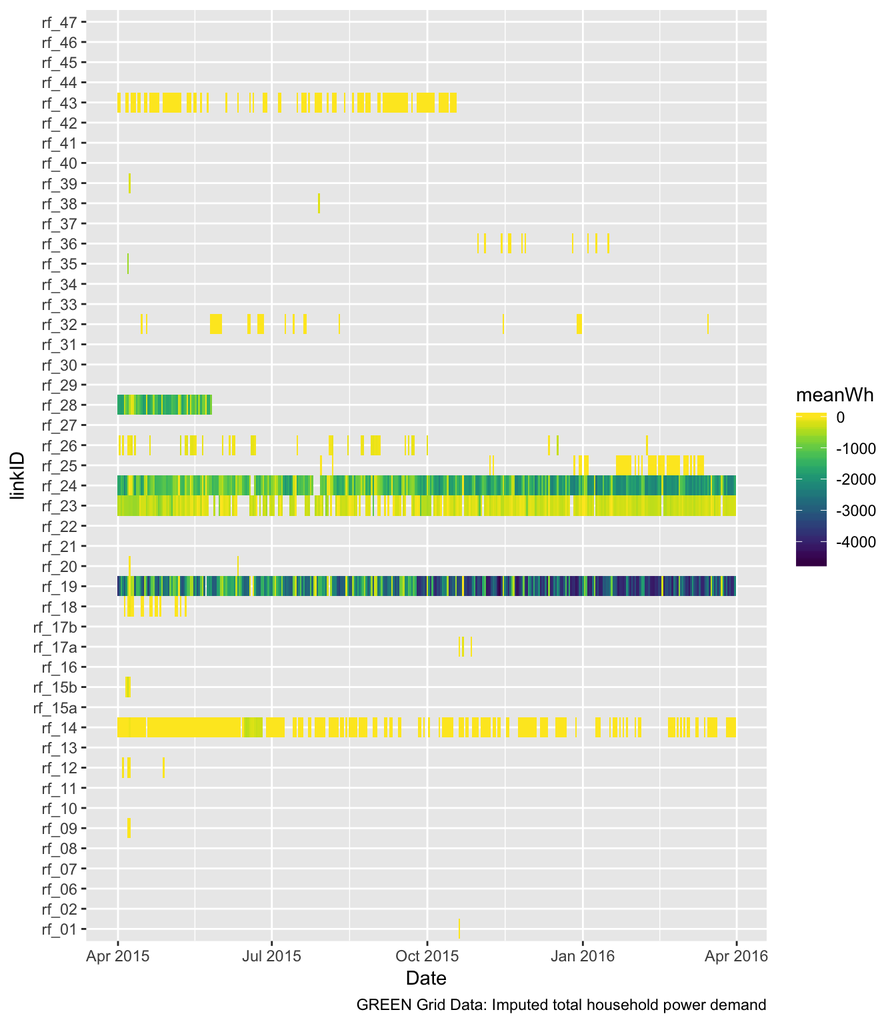

Figure 4.2: Mean of -ve values by household ID and date and presence of PV (if known)

# 5 Test power profiles

Next we test the power profiles by season to see if there is a seasonal pattern to the negatuive values which might indicate unreported PV (for example).

First we create a *Southern* Hemisphere season variable. We have a function to do this in the `GREENGridData` package. We print a check table to ensure we are all happy with the coding of `season`.

```r
powerDT <- powerDT[, r_dateTime := dateTime_utc] # for consistency
powerDT <- GREENGridData::addNZSeason(powerDT)
table(lubridate::month(powerDT$r_dateTime, label = TRUE), powerDT$season, useNA = "always")
```

```
##
##         Spring  Summer  Autumn  Winter    <NA>
##   Jan        0 1320098       0       0       0
##   Feb        0 1242289       0       0       0
##   Mar        0       0 1319064       0       0
##   Apr        0       0 1772066       0       0
##   May        0       0 1803659       0       0
##   Jun        0       0       0 1667483       0
##   Jul        0       0       0 1655159       0
##   Aug        0       0       0 1597576       0
##   Sep  1528022       0       0       0       0
##   Oct  1550745       0       0       0       0
##   Nov  1397910       0       0       0       0
##   Dec        0 1334594       0       0       0
##   <NA>       0       0       0       0       0
```

Figure 5.1 plots overall mean power per minute by season and household id.

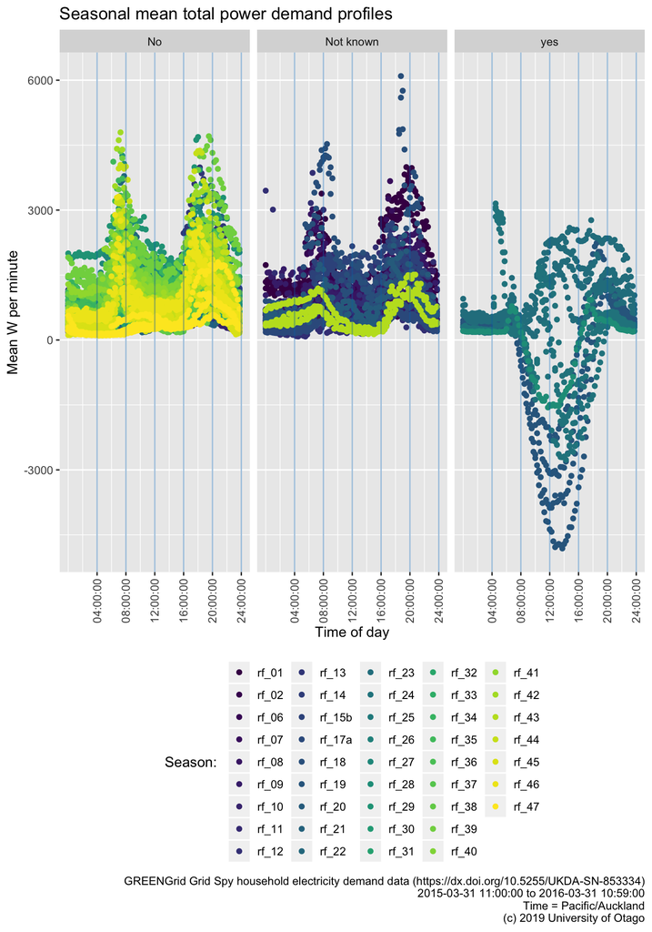

Figure 5.1: Mean total demand profile plot

If a household has PV this should be clearly visible as a -ve curve centered on ~ 12:00 - 13:00.

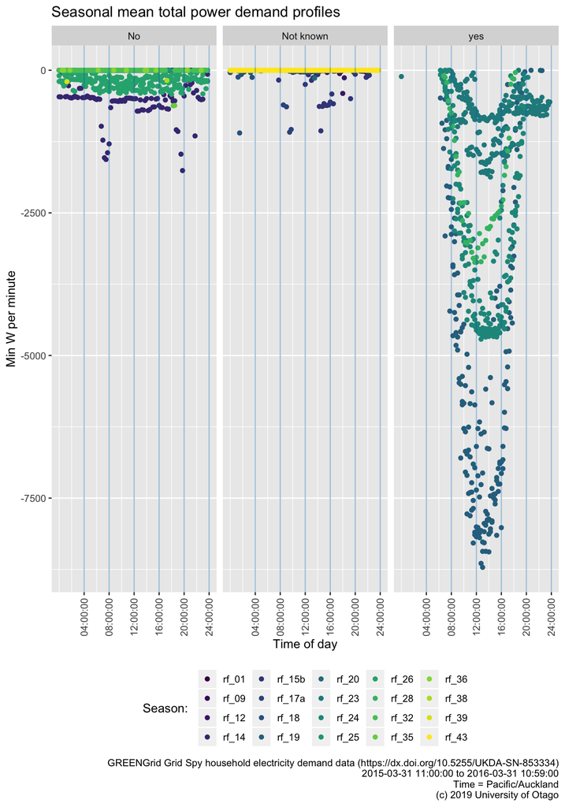

Figure 5.2: Minimum total demand profile plot

Figure 5.2 repeats this analysis but for minimum power per minute by season and household id and plots only those values that are <= 0 to clarify time of day effects on -ve values.

# 6 Implications

In *all* cases we recommend that users check the data carefully before anlaysis and *document* anY filtering they apply!

# 7 Statistical Annex

## 7.1 Power data

```
## Skim summary statistics
##  n obs: 18188665
##  n variables: 8
##
## ── Variable type:character ──────────────────────────────────────────────────────────────────────────────────────────────────────────────────
##  variable missing complete        n min max empty n_unique
##    linkID       0 18188665 18188665   5   6     0       43
##
## ── Variable type:difftime ───────────────────────────────────────────────────────────────────────────────────────────────────────────────────
##         variable missing complete        n    min        max   median
##       obsTimeHMS       0 18188665 18188665 0 secs 86340 secs 11:59:00
##  obsTimeHMSQHour       0 18188665 18188665 0 secs 85500 secs 11:45:00
##  n_unique
##      1440
##        96
##
## ── Variable type:factor ─────────────────────────────────────────────────────────────────────────────────────────────────────────────────────
##  variable missing complete        n n_unique
##    season       0 18188665 18188665        4
##                                              top_counts ordered
##  Win: 4920218, Aut: 4894789, Spr: 4476677, Sum: 3896981   FALSE
##
## ── Variable type:numeric ────────────────────────────────────────────────────────────────────────────────────────────────────────────────────
##       variable missing complete        n   mean      sd      p0    p25
##  imputedTotalW       0 18188665 18188665 887.95 1279.14 -8713.1 206.33
##     p50     p75     p100     hist
##  417.33 1158.28 13999.81 ▁▁▁▇▁▁▁▁
##
## ── Variable type:POSIXct ────────────────────────────────────────────────────────────────────────────────────────────────────────────────────
##      variable missing complete        n        min        max     median
##   dateTime_nz       0 18188665 18188665 2015-04-01 2016-03-31 2015-09-12
##  dateTime_utc       0 18188665 18188665 2015-03-31 2016-03-31 2015-09-12
##    r_dateTime       0 18188665 18188665 2015-03-31 2016-03-31 2015-09-12
##  n_unique
##    526980
##    526980
##    526980
```

## 7.2 Household data

```
## Skim summary statistics
##  n obs: 44
##  n variables: 110
##
## ── Variable type:character ──────────────────────────────────────────────────────────────────────────────────────────────────────────────────
##             variable missing complete  n min max empty n_unique
##        Clothes Dryer      23       21 44   3   3     0        1
##           Dishwasher      15       29 44   3   3     0        1
##      Electric heater      30       14 44   3   3     0        1
##       Energy Storage      43        1 44   3   3     0        1
##   Fridge / Freezer 1      13       31 44   3   3     0        1
##   Fridge / Freezer 2      24       20 44   3   3     0        1
##   Fridge / Freezer 3      38        6 44   3   3     0        1
##  hasApplianceSummary      13       31 44   3   3     0        1
##        hasLongSurvey      15       29 44   3   3     0        1
##       hasShortSurvey      31       13 44   3   3     0        1
##   Heated towel rails      23       21 44   3   3     0        1
##                 hhID       0       44 44   5   5     0       42
##   Hot water cylinder      16       28 44   3   3     0        1
##               linkID       0       44 44   5   6     0       44
##             Location       0       44 44  10  12     0        2
##            Microwave      14       30 44   3   3     0        1
##                notes      39        5 44   7  81     0        5
##      Other Appliance      30       14 44   3  42     0        8
##                 Oven      14       30 44   3   3     0        1
##          PV Inverter      40        4 44   3   3     0        1
##            StartDate       2       42 44  16  16     0       42
##      Washing Machine      13       31 44   3   3     0        1
##
## ── Variable type:Date ───────────────────────────────────────────────────────────────────────────────────────────────────────────────────────
##    variable missing complete  n        min        max     median n_unique
##  r_stopDate      41        3 44 2015-01-15 2016-04-02 2016-03-28        3
##
## ── Variable type:logical ────────────────────────────────────────────────────────────────────────────────────────────────────────────────────
##                 variable missing complete  n mean count
##  Other Generation Device      44        0 44  NaN    44
##                   Q19_10      44        0 44  NaN    44
##                 Q19_10.1      44        0 44  NaN    44
##                   Q19_17      44        0 44  NaN    44
##                    Q19_2      44        0 44  NaN    44
```

[output cut: 155 more lines]

```
##    0       0 ▁▁▁▇▁▁▁▁
##  100.75  451 ▇▆▁▁▁▁▁▁
##  385     500 ▆▃▂▂▆▂▁▇
##    0     140 ▇▁▁▁▁▁▁▁
##    0       0 ▁▁▁▇▁▁▁▁
##   16      26 ▂▃▇▅▃▅▁▁
##    4       6 ▃▇▁▇▇▁▃▂
##   49      64 ▆▇▃▅▇▂▁▂
##    3       4 ▇▁▅▁▁▃▁▂
##
## ── Variable type:POSIXct ────────────────────────────────────────────────────────────────────────────────────────────────────────────────────
##         variable missing complete  n        min        max     median
##  surveyStartDate       2       42 44 2014-05-14 2015-02-10 2014-06-19
##  n_unique
##        42
```

# 8 Runtime

Analysis completed in 130.69 seconds ( 2.18 minutes) using knitr in [RStudio](http://www.rstudio.com) with R version 3.5.2 (2018-12-20) running on x86_64-apple-darwin15.6.0.

# 9 R environment

## 9.1 R packages used

- base R (R Core Team 2016)
- bookdown (Xie 2016a)
- ggplot2 (Wickham 2009)
- here (Müller 2017)
- GREENGridData (Anderson and Eyers 2018) which depends on:
  - data.table (Dowle et al. 2015)
  - dplyr (Wickham and Francois 2016)
  - hms (Müller 2018)
  - lubridate (Grolemund and Wickham 2011)
  - progress (Csárdi and FitzJohn 2016)
  - readr (Wickham, Hester, and Francois 2016)
  - readxl (Wickham and Bryan 2017)
  - reshape2 (Wickham 2007)
- kableExtra (Zhu 2018)
- knitr (Xie 2016b)
- rmarkdown (Allaire et al. 2018)

# References

Allaire, JJ, Yihui Xie, Jonathan McPherson, Javier Luraschi, Kevin Ushey, Aron Atkins, Hadley Wickham, Joe Cheng, and Winston Chang. 2018. *Rmarkdown: Dynamic Documents for R*. https://CRAN.R-project.org/package=rmarkdown.

Anderson, Ben, and David Eyers. 2018. *GREENGridData: Processing Nz Green Grid Project Data to Create a ’Safe’ Version for Data Archiving and Re-Use*. https://github.com/CfSOtago/GREENGridData.

Csárdi, Gábor, and Rich FitzJohn. 2016. *Progress: Terminal Progress Bars*. https://CRAN.R-project.org/package=progress.

Dowle, M, A Srinivasan, T Short, S Lianoglou with contributions from R Saporta, and E Antonyan. 2015. *Data.table: Extension of Data.frame*. https://CRAN.R-project.org/package=data.table.

Grolemund, Garrett, and Hadley Wickham. 2011. “Dates and Times Made Easy with lubridate.” *Journal of Statistical Software* 40 (3): 1–25. http://www.jstatsoft.org/v40/i03/.

Müller, Kirill. 2017. *Here: A Simpler Way to Find Your Files*. https://CRAN.R-project.org/package=here.

———. 2018. *Hms: Pretty Time of Day*. https://CRAN.R-project.org/package=hms.

R Core Team. 2016. *R: A Language and Environment for Statistical Computing*. Vienna, Austria: R Foundation for Statistical Computing. https://www.R-project.org/.

Stephenson, Janet, Rebecca Ford, Nirmal-Kumar Nair, Neville Watson, Alan Wood, and Allan Miller. 2017. “Smart Grid Research in New Zealand–A Review from the GREEN Grid Research Programme.” *Renewable and Sustainable Energy Reviews* 82 (1): 1636–45. https://doi.org/10.1016/j.rser.2017.07.010.

Wickham, Hadley. 2007. “Reshaping Data with the reshape Package.” *Journal of Statistical Software* 21 (12): 1–20. http://www.jstatsoft.org/v21/i12/.

———. 2009. *Ggplot2: Elegant Graphics for Data Analysis*. Springer-Verlag New York. http://ggplot2.org.

Wickham, Hadley, and Jennifer Bryan. 2017. *Readxl: Read Excel Files*. https://CRAN.R-project.org/package=readxl.

Wickham, Hadley, and Romain Francois. 2016. *Dplyr: A Grammar of Data Manipulation*. https://CRAN.R-project.org/package=dplyr.

Wickham, Hadley, Jim Hester, and Romain Francois. 2016. *Readr: Read Tabular Data*. https://CRAN.R-project.org/package=readr.

Xie, Yihui. 2016a. *Bookdown: Authoring Books and Technical Documents with R Markdown*. Boca Raton, Florida: Chapman; Hall/CRC. https://github.com/rstudio/bookdown.

———. 2016b. *Knitr: A General-Purpose Package for Dynamic Report Generation in R*. https://CRAN.R-project.org/package=knitr.

Zhu, Hao. 2018. *KableExtra: Construct Complex Table with ’Kable’ and Pipe Syntax*. https://CRAN.R-project.org/package=kableExtra.